# FIT5145 Assessment 2

#### Student Name: Linus McManamey

#### Student ID: 27236463

Date: 05/02/2017

Version: 1.0

Environment: Python 2.7.11 and Jupyter notebook

```python
from pandas import *
import geocoder
import pandas as pd
import numpy as np
import matplotlib
import matplotlib.pyplot as plt
import time
import seaborn as sns
from IPython.core.interactiveshell import InteractiveShell
InteractiveShell.ast_node_interactivity = "all"
%matplotlib inline
```

### PLOTLY LIBRARIES

```python
import plotly
import cufflinks as cf
plotly.tools.set_credentials_file(username='linus.austen.mcmanamey', api_key='3tqgEzyZAGTIeFY5sQ1T')
import plotly.plotly as py
import plotly.graph_objs as go
from plotly.graph_objs import *
from plotly.graph_objs import Surface, Layout, Scene
from plotly.grid_objs import Grid, Column
from plotly.tools import FigureFactory as FF
from plotly.offline import init_notebook_mode, iplot
from IPython.display import display, HTML
init_notebook_mode(connected=True)
import plotly.tools as tls
import colorlover as cl
```

```python
### CONSTANTS
SPEED = 1200
EASER = 'linear'
```

```python
#! conda install --channel https://conda.anaconda.org/conda-forge plotly=1.13.0
```

```python
#! pip install cufflinks --upgrade
```

```python
#!pip install geocoder
```

# Part A: Motion Chart

## Task 1

#### List all csv files in directory

```python
!ls *.csv
```

```
database.csv		     pollution_us_2000_2016.csv  us_statedata.csv
ERP_by state and gender.csv  Rate.csv
Job Vacancies.csv	     sampleRate.csv
```

#### List all excel files in directory

```python
!ls *.xls
```

```
SA4 Time Series - October 2016.xls  test.xls  us_statedata.xls
```

```python
SA4 = pd.read_excel('SA4 Time Series - October 2016.xls', sheetname = 'Time Series') # we will have to specify the sheet name
SA4.head(5)
```

|  | State/Territory | Date | Employment Rate (15-64) | Unemployment Rate (15+) | Participation Rate (15+) |
| --- | --- | --- | --- | --- | --- |
| 0 | NSW | 1978-02-01 | n/a | 6.773762 | 60.735313 |
| 1 | NSW | 1978-03-01 | n/a | 6.490161 | 59.851078 |
| 2 | NSW | 1978-04-01 | 63.7195 | 6.507978 | 60.168513 |
| 3 | NSW | 1978-05-01 | 63.682 | 6.115171 | 60.003564 |
| 4 | NSW | 1978-06-01 | 63.6829 | 6.424127 | 60.145380 |

#### Rename columns

```python
SA4 = SA4.rename(columns={'State/Territory':'State'})
SA4 = SA4.rename(columns={'Employment Rate (15-64)':'E_Rate'})
SA4 = SA4.rename(columns={'Unemployment Rate (15+)':'U_Rate'})
SA4 = SA4.rename(columns={'Participation Rate (15+)':'P_Rate'})
SA4.head(2)
```

|  | State | Date | E_Rate | U_Rate | P_Rate |
| --- | --- | --- | --- | --- | --- |
| 0 | NSW | 1978-02-01 | n/a | 6.773762 | 60.735313 |
| 1 | NSW | 1978-03-01 | n/a | 6.490161 | 59.851078 |

```python
print("check for number of n/a's  in E_Rate")
len(SA4[SA4.E_Rate  == 'n/a'])
```

```
check for number of n/a's  in E_Rate
```

```
16
```

#### Remove 'n/a' and cast as float

```python
SA4 = SA4[SA4.E_Rate  != 'n/a']
SA4.E_Rate = SA4.E_Rate.astype('float')
print(len(SA4))
```

```
3704
```

#### Check dataframe types

```python
SA4.dtypes
```

```
State             object
Date      datetime64[ns]
E_Rate           float64
U_Rate           float64
P_Rate           float64
dtype: object
```

#### Check for null values

```python
SA4.U_Rate.isnull().sum()
SA4.P_Rate.isnull().sum()
SA4.E_Rate.isnull().sum()
```

```
0
```

```
0
```

```
0
```

#### Set Date as index and then remove "Date" column

```python
SA4.index = pd.to_datetime(SA4.Date)
SA4 = SA4.drop('Date', axis=1)
SA4.head(2)
```

| Date | State | E_Rate | U_Rate | P_Rate |
| --- | --- | --- | --- | --- |
| 1978-04-01 | NSW | 63.719468 | 6.507978 | 60.168513 |
| 1978-05-01 | NSW | 63.682010 | 6.115171 | 60.003564 |

#### Import csv files to pandas data frame

```python
ERP = pd.read_csv('ERP_by state and gender.csv',infer_datetime_format=True,parse_dates=True, index_col=0)
jobVacDF = pd.read_csv('Job Vacancies.csv',header=0,index_col=0, infer_datetime_format=True, parse_dates=True)
```

```python
jobVacDF.head(2)
```

| State | 2006-01-01 | 2006-02-01 | 2006-03-01 | 2006-04-01 | 2006-05-01 | 2006-06-01 | 2006-07-01 | 2006-08-01 | 2006-09-01 | 2006-10-01 | ... | 2016-01-01 | 2016-02-01 | 2016-03-01 | 2016-04-01 | 2016-05-01 | 2016-06-01 | 2016-07-01 | 2016-08-01 | 2016-09-01 | 2016-10-01 |
| --- | --- | --- | --- | --- | --- | --- | --- | --- | --- | --- | --- | --- | --- | --- | --- | --- | --- | --- | --- | --- | --- |
| NSW | 73047.8 | 73995.0 | 75246.3 | 76539.8 | 75614.9 | 81637.1 | 77047.4 | 78148.5 | 76411.3 | 82945.5 | ... | 65297.0 | 64206.1 | 63909.2 | 65951.1 | 66060.8 | 66225.8 | 65063.3 | 65154.9 | 63121.4 | 63534.1 |
| VIC | 49399.3 | 51027.9 | 51492.4 | 51473.1 | 50570.0 | 53746.2 | 52149.5 | 52783.5 | 51013.6 | 56556.5 | ... | 42227.9 | 41179.8 | 40338.7 | 42380.6 | 42968.9 | 42947.6 | 42292.8 | 42511.9 | 40092.0 | 42182.9 |

2 rows × 130 columns

#### Transpose dataframe

```python
jobVacDF = jobVacDF.T
```

```python
jobVacDF.head(5)
```

| State | NSW | VIC | QLD | SA | WA | TAS | NT | ACT |
| --- | --- | --- | --- | --- | --- | --- | --- | --- |
| 2006-01-01 | 73047.8 | 49399.3 | 49807.5 | 13111.4 | 18087.6 | 2895.0 | 2563.0 | 3165.3 |
| 2006-02-01 | 73995.0 | 51027.9 | 49526.3 | 13160.9 | 18943.3 | 2874.7 | 2402.0 | 3335.5 |
| 2006-03-01 | 75246.3 | 51492.4 | 49233.0 | 13669.6 | 19739.3 | 3272.3 | 2485.0 | 3473.9 |
| 2006-04-01 | 76539.8 | 51473.1 | 50440.4 | 13308.7 | 19854.2 | 2833.2 | 2590.6 | 3493.0 |
| 2006-05-01 | 75614.9 | 50570.0 | 51387.3 | 13095.8 | 20351.9 | 2747.1 | 2805.4 | 3666.7 |

#### Convert index column to datetime value

```python
jobVacDF.index = pd.to_datetime(jobVacDF.index)
```

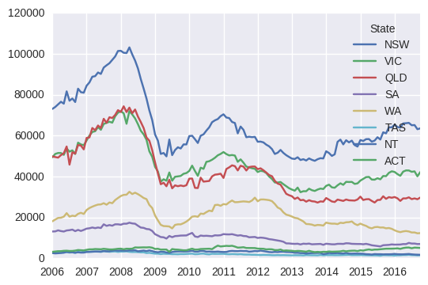

```python
jobVacDF['2006-01-01':'2016-10-01'].plot()
```

## Plot - Number of Job Vacancies per year by State

```python
data = []
for (name, series) in jobVacDF.iteritems():
            data.append(dict(type='scatter', mode='lines',x=jobVacDF.index, y=jobVacDF[name], name=jobVacDF[name].name))

layout = dict(title='Number of Job Vacancies per year by State',showlegend=True)
fig = dict(data=data, layout=layout)
py.iplot(fig, filename = 'Number_of_Job_Vacancies_per_year_by_State')
```

[interactive chart not shown]

#### Rename Estimated Resident Population dataframe columns

```python
ERP = ERP.rename(columns={'Estimated Resident Population ;  Male ;  New South Wales ;':'NSW_Male'})
ERP = ERP.rename(columns={'Estimated Resident Population ;  Male ;  Victoria ;':'VIC_Male'})
ERP = ERP.rename(columns={'Estimated Resident Population ;  Male ;  Queensland ;':'QLD_Male'})
ERP = ERP.rename(columns={'Estimated Resident Population ;  Male ;  South Australia ;':'SA_Male'})
ERP = ERP.rename(columns={'Estimated Resident Population ;  Male ;  Western Australia ;':'WA_Male'})
ERP = ERP.rename(columns={'Estimated Resident Population ;  Male ;  Tasmania ;':'TAS_Male'})
ERP = ERP.rename(columns={'Estimated Resident Population ;  Male ;  Northern Territory ;':'NT_Male'})
ERP = ERP.rename(columns={'Estimated Resident Population ;  Male ;  Australian Capital Territory ;':'ACT_Male'})
ERP = ERP.rename(columns={'Estimated Resident Population ;  Male ;  Australia ;':'AUST_Male'})

ERP = ERP.rename(columns={'Estimated Resident Population ;  Female ;  New South Wales ;':'NSW_Female'})
ERP = ERP.rename(columns={'Estimated Resident Population ;  Female ;  Victoria ;':'VIC_Female'})
ERP = ERP.rename(columns={'Estimated Resident Population ;  Female ;  Queensland ;':'QLD_Female'})
ERP = ERP.rename(columns={'Estimated Resident Population ;  Female ;  South Australia ;':'SA_Female'})
ERP = ERP.rename(columns={'Estimated Resident Population ;  Female ;  Western Australia ;':'WA_Female'})
ERP = ERP.rename(columns={'Estimated Resident Population ;  Female ;  Tasmania ;':'TAS_Female'})
ERP = ERP.rename(columns={'Estimated Resident Population ;  Female ;  Northern Territory ;':'NT_Female'})
ERP = ERP.rename(columns={'Estimated Resident Population ;  Female ;  Australian Capital Territory ;':'ACT_Female'})
ERP = ERP.rename(columns={'Estimated Resident Population ;  Female ;  Australia ;':'AUST_Female'})


ERP = ERP.rename(columns={'Estimated Resident Population ;  Persons ;  New South Wales ;':'NSW_Persons'})
ERP = ERP.rename(columns={'Estimated Resident Population ;  Persons ;  Victoria ;':'VIC_Persons'})
ERP = ERP.rename(columns={'Estimated Resident Population ;  Persons ;  Queensland ;':'QLD_Persons'})
ERP = ERP.rename(columns={'Estimated Resident Population ;  Persons ;  South Australia ;':'SA_Persons'})
ERP = ERP.rename(columns={'Estimated Resident Population ;  Persons ;  Western Australia ;':'WA_Persons'})
ERP = ERP.rename(columns={'Estimated Resident Population ;  Persons ;  Tasmania ;':'TAS_Persons'})
ERP = ERP.rename(columns={'Estimated Resident Population ;  Persons ;  Northern Territory ;':'NT_Persons'})
ERP = ERP.rename(columns={'Estimated Resident Population ;  Persons ;  Australian Capital Territory ;':'ACT_Persons'})
ERP = ERP.rename(columns={'Estimated Resident Population ;  Persons ;  Australia ;':'TOTAL'})
```

#### Convert index column to datetime value

```python
ERP.index = pd.to_datetime(ERP.index)
```

```python
ERP.head(2)
```

|  | NSW_Male | VIC_Male | QLD_Male | SA_Male | WA_Male | TAS_Male | NT_Male | ACT_Male | AUST_Male | NSW_Female | ... | AUST_Female | NSW_Persons | VIC_Persons | QLD_Persons | SA_Persons | WA_Persons | TAS_Persons | NT_Persons | ACT_Persons | TOTAL |
| --- | --- | --- | --- | --- | --- | --- | --- | --- | --- | --- | --- | --- | --- | --- | --- | --- | --- | --- | --- | --- | --- |
| 2005-12-01 | 3327461 | 2481962 | 1977783 | 762665 | 1022918 | 240625 | 107839 | 164850 | 10087382 | 3390562 | ... | 10224161 | 6718023 | 5023203 | 3964175 | 1544852 | 2029936 | 488098 | 207385 | 333505 | 20311543 |
| 2006-03-01 | 3336005 | 2495951 | 1989764 | 765272 | 1030021 | 241193 | 108137 | 165351 | 10132982 | 3399523 | ... | 10265150 | 6735528 | 5048207 | 3987653 | 1550135 | 2042450 | 489140 | 208347 | 334299 | 20398132 |

2 rows × 27 columns

#### Break down dataframes in to population totals by state

```python
maleDF = ERP[[col for col in ERP.columns if "Male" in col]]
femaleDF = ERP[[col for col in ERP.columns if "Female" in col]]
personDF = ERP[[col for col in ERP.columns if "Persons" in col]]
```

#### Rename to population totals by state

```python
personDF = personDF.rename(columns={'NSW_Persons':'NSW'})
personDF = personDF.rename(columns={'VIC_Persons':'VIC'})
personDF = personDF.rename(columns={'QLD_Persons':'QLD'})
personDF = personDF.rename(columns={'SA_Persons':'SA'})
personDF = personDF.rename(columns={'WA_Persons':'WA'})
personDF = personDF.rename(columns={'TAS_Persons':'TAS'})
personDF = personDF.rename(columns={'NT_Persons':'NT'})
personDF = personDF.rename(columns={'ACT_Persons':'ACT'})
```

```python
populationDF = personDF.copy()
```

## Initial plot to check populationDF working

```python
data = []
for (name, series) in populationDF.iteritems():
            data.append(dict(type='scatter', mode='lines',x=populationDF.index, y=populationDF[name], name=populationDF[name].name))


layout = dict(title='Population States of Australia',showlegend=True)
fig = dict(data=data, layout=layout)
py.iplot(fig, filename = 'Population_States_of_Australia')
```

[interactive chart not shown]

#### Retrive list of dates from index of population dataframe and subset other dataframes for the same dates

```python
baseDates = populationDF.index.tolist()
jobVacDF = jobVacDF.ix[baseDates]
SA4 = SA4.ix[baseDates]
```

```python
jobVacDF.head(2)
populationDF.head(2)
SA4.head(2)
```

| State | NSW | VIC | QLD | SA | WA | TAS | NT | ACT |
| --- | --- | --- | --- | --- | --- | --- | --- | --- |
| 2005-12-01 | NaN | NaN | NaN | NaN | NaN | NaN | NaN | NaN |
| 2006-03-01 | 75246.3 | 51492.4 | 49233.0 | 13669.6 | 19739.3 | 3272.3 | 2485.0 | 3473.9 |

|  | NSW | VIC | QLD | SA | WA | TAS | NT | ACT |
| --- | --- | --- | --- | --- | --- | --- | --- | --- |
| 2005-12-01 | 6718023 | 5023203 | 3964175 | 1544852 | 2029936 | 488098 | 207385 | 333505 |
| 2006-03-01 | 6735528 | 5048207 | 3987653 | 1550135 | 2042450 | 489140 | 208347 | 334299 |

| Date | State | E_Rate | U_Rate | P_Rate |
| --- | --- | --- | --- | --- |
| 2005-12-01 | NSW | 70.481740 | 5.293757 | 63.106123 |
| 2005-12-01 | VIC | 71.806591 | 5.260037 | 64.045364 |

#### Drop All NAN rows

```python
populationDF = populationDF.dropna(how='any')
jobVacDF = jobVacDF.dropna(how='any')
```

#### chage structure of dataframe to match other two

- Extract the unemployment rate

```python
print("Before_____________")
SA4.head(2)
unemploymentDF = SA4.pivot(columns='State', values='U_Rate')
del unemploymentDF.index.name
print("After_____________")
unemploymentDF.head(2)
```

```
Before_____________
```

| Date | State | E_Rate | U_Rate | P_Rate |
| --- | --- | --- | --- | --- |
| 2005-12-01 | NSW | 70.481740 | 5.293757 | 63.106123 |
| 2005-12-01 | VIC | 71.806591 | 5.260037 | 64.045364 |

```
After_____________
```

| State | ACT | NSW | NT | QLD | SA | TAS | VIC | WA |
| --- | --- | --- | --- | --- | --- | --- | --- | --- |
| 2005-12-01 | 3.422536 | 5.293757 | 6.004577 | 4.863610 | 4.868181 | 5.962563 | 5.260037 | 4.326411 |
| 2006-03-01 | 3.254369 | 4.978780 | 5.765331 | 4.705125 | 5.035000 | 6.608448 | 5.112932 | 3.988064 |

#### Check structure an print

```python
print(len(jobVacDF))
jobVacDF.head(2)
print(len(populationDF))
populationDF.head(2)
print(len(unemploymentDF))
unemploymentDF.head(2)
```

```
38
```

| State | NSW | VIC | QLD | SA | WA | TAS | NT | ACT |
| --- | --- | --- | --- | --- | --- | --- | --- | --- |
| 2006-03-01 | 75246.3 | 51492.4 | 49233.0 | 13669.6 | 19739.3 | 3272.3 | 2485.0 | 3473.9 |
| 2006-06-01 | 81637.1 | 53746.2 | 54667.4 | 13611.8 | 22077.5 | 2978.1 | 3201.0 | 3719.0 |

```
39
```

|  | NSW | VIC | QLD | SA | WA | TAS | NT | ACT |
| --- | --- | --- | --- | --- | --- | --- | --- | --- |
| 2005-12-01 | 6718023 | 5023203 | 3964175 | 1544852 | 2029936 | 488098 | 207385 | 333505 |
| 2006-03-01 | 6735528 | 5048207 | 3987653 | 1550135 | 2042450 | 489140 | 208347 | 334299 |

```
39
```

| State | ACT | NSW | NT | QLD | SA | TAS | VIC | WA |
| --- | --- | --- | --- | --- | --- | --- | --- | --- |
| 2005-12-01 | 3.422536 | 5.293757 | 6.004577 | 4.863610 | 4.868181 | 5.962563 | 5.260037 | 4.326411 |
| 2006-03-01 | 3.254369 | 4.978780 | 5.765331 | 4.705125 | 5.035000 | 6.608448 | 5.112932 | 3.988064 |

#### Drop first row so dates indexes are the same for each dataframe

```python
unemploymentDF = unemploymentDF.drop(unemploymentDF.index[[0]])
populationDF = populationDF.drop(populationDF.index[[0]])
```

```python
print(len(jobVacDF))
jobVacDF.head(2)
print(len(populationDF))
populationDF.head(2)
print(len(unemploymentDF))
unemploymentDF.head(2)
```

```
38
```

| State | NSW | VIC | QLD | SA | WA | TAS | NT | ACT |
| --- | --- | --- | --- | --- | --- | --- | --- | --- |
| 2006-03-01 | 75246.3 | 51492.4 | 49233.0 | 13669.6 | 19739.3 | 3272.3 | 2485.0 | 3473.9 |
| 2006-06-01 | 81637.1 | 53746.2 | 54667.4 | 13611.8 | 22077.5 | 2978.1 | 3201.0 | 3719.0 |

```
38
```

|  | NSW | VIC | QLD | SA | WA | TAS | NT | ACT |
| --- | --- | --- | --- | --- | --- | --- | --- | --- |
| 2006-03-01 | 6735528 | 5048207 | 3987653 | 1550135 | 2042450 | 489140 | 208347 | 334299 |
| 2006-06-01 | 6742690 | 5061266 | 4007992 | 1552529 | 2050581 | 489302 | 209057 | 335170 |

```
38
```

| State | ACT | NSW | NT | QLD | SA | TAS | VIC | WA |
| --- | --- | --- | --- | --- | --- | --- | --- | --- |
| 2006-03-01 | 3.254369 | 4.978780 | 5.765331 | 4.705125 | 5.035000 | 6.608448 | 5.112932 | 3.988064 |
| 2006-06-01 | 3.004263 | 5.288439 | 4.942226 | 4.500243 | 4.730513 | 6.669892 | 5.021526 | 3.351213 |

```python
dataset = pd.DataFrame()
dataset['unemployment'] = unemploymentDF.unstack()
dataset['population'] = populationDF.unstack()
dataset['jobVacancies'] = jobVacDF.unstack()
```

```python
dataset.reset_index(level=0, inplace=True)
```

### Plot table of dataframe

```python
table = FF.create_table(dataset.head(10))
py.iplot(table)
```

[interactive chart not shown]

# Generate a Motion chart

- number of job vacancies on the x-axis,
- unemployment rate on the y-axis,
- the colour the bubbles is given by the state and the size of the bubbles is given by the population of the state.

```python
years = dataset.index.unique()
years = years.strftime('%Y-%m-%d')
years = sorted(years)
states = dataset.State.unique()
states = sorted(states)
figure = {
    'data': [],
    'layout': {},
    'frames': [],
    'config': {'scrollzoom': True}
}

# fill in most of layout
figure['layout']['xaxis'] = {'range': [ dataset.jobVacancies.min(), dataset.jobVacancies.max()],'title': 'Job Vacancies'}
figure['layout']['yaxis'] = {'range': [ dataset.unemployment.min(), dataset.unemployment.max()],'title': 'unemployment', 'type':'linear'}
figure['layout']['hovermode'] = 'closest'
#figure['layout']['autosize'] = False
figure['layout']['Margin']  = {'l':50, 'r': 50, 'b': 100, 't': 100, 'pad':4}
```

```python
figure['layout']['updatemenus'] = [
    {
        'buttons': [
            {
                'args': [None, {'frame': {'duration': SPEED, 'redraw': False},'fromcurrent': False,
                                'transition': {'duration': SPEED, 'easing': EASER}}],
                'label': 'Play','method': 'animate'},
            {
                'args': [[None], {'frame': {'duration': SPEED, 'redraw': False}, 'mode': 'immediate',
                'transition': {'duration': SPEED}}],
                'label': 'Pause',
                'method': 'animate'
            }
        ],
        'direction': 'left',
        'pad': {'r': 10, 't': 10},
        'showactive': True,
        'type': 'buttons',
        'x': 0.1,
        'xanchor': 'right',
        'y': 0,
        'yanchor': 'top'
    }
]
```

```python
sliders_dict = {
    'active': 1,
    'yanchor': 'top',
    'xanchor': 'left',
    'currentvalue': {
        'font': {'size': 20},
        'prefix': 'Year: ',
        'visible': True,
        'xanchor': 'right'
    },
    'transition': {'duration': SPEED, 'easing': EASER},
    'pad': {'b': 1, 't': 1},
    'len': 0.9,
    'x': 0.1,
    'y': 0,
    'steps': []
}
```

```python
figure['layout']['slider'] = {
    'args': [
        'slider.value', {
            'duration': SPEED,
            'ease': EASER
        }
    ],
    'initialValue': years[0],
    'plotlycommand': 'animate',
    'values': years,
    'visible': True
}
```

```python
for state in states:
    dataset_by_state = dataset[dataset['State'] == state]
    figure['data'].append(dict(text=state,
                               hoverinfo ="all",
                               type='scatter',
                               x=dataset_by_state['jobVacancies'],
                               y=dataset_by_state['unemployment'],
                               name=state,mode='markers',
                               marker=dict(symbol='circle',
                                           size=dataset_by_state['population']/10000,
                                           sizeref=2,
                                           sizemode='radius')))
```

```python
year = years[0]
for year in years:
    frame = {'data': [], 'name': str(year)}
    for state in states:
        dataset_by_state = dataset[dataset.index == year]
        dataset_by_state = dataset_by_state[dataset_by_state['State'] == state]
        frame['data'].append(dict(text=state,
                                  hoverinfo ="all",
                                  type='scatter',
                                  x=dataset_by_state['jobVacancies'],
                                  y=dataset_by_state['unemployment'],
                                  name=state,mode='markers',
                                  marker=dict(symbol='circle',
                                              size=dataset_by_state['population']/10000 ,
                                              sizeref=2,
                                              sizemode='radius')))

    figure['frames'].append(frame)
    slider_step = {'args': [[year],{'frame': {'duration': SPEED, 'redraw': False},
         'mode': 'immediate','transition': {'duration': SPEED,  'easing': EASER}}],'label': year,'method': 'animate'}
    sliders_dict['steps'].append(slider_step)


figure['layout']['sliders'] = [sliders_dict]
iplot(figure)
```

[interactive chart not shown]

# Questions - Task 1

### Which state has high unemployment rate and low number of vacancies (you may point out different period of time)?

Tasmania

### which state has the low unemployment rate but with a lot of vacancies? Any idea about why?

New South Wales.

# Part 2

Twitter data from the various Australian Government departments was used for this task.

APS Twitter Leaderboard

https://www.data.gov.au/dataset/aps-twitter-leaderboard

#### List all files in the dataFile directory

```python
!ls dataFiles/*.csv
```

```
dataFiles/twitterfollowers-2014-09-01.csv
dataFiles/twitterfollowers-2014-10-02.csv
dataFiles/twitterfollowers-2014-11-03.csv
dataFiles/twitterfollowers-2014-12-03.csv
dataFiles/twitterfollowers-2015-01-03.csv
dataFiles/twitterfollowers-2015-02-03.csv
dataFiles/twitterfollowers-2015-03-03.csv
dataFiles/twitterfollowers-2015-04-02.csv
dataFiles/twitterfollowers-2015-05-02.csv
dataFiles/twitterfollowers-2015-06-02.csv
dataFiles/twitterfollowers-2015-07-03.csv
dataFiles/twitterfollowers-2015-08-03.csv
dataFiles/twitterfollowers-2015-09-02.csv
dataFiles/twitterfollowers-2015-10-02.csv
dataFiles/twitterfollowers-2015-11-03.csv
dataFiles/twitterfollowers-2015-12-03.csv
dataFiles/twitterfollowers-2016-01-05.csv
```

#### The top sixteen government departments (most followers) from the most recent file were used

```python
top16 = pd.read_csv('dataFiles/twitterfollowers-2016-01-05.csv')
top16 = top16.nlargest(16, 'End of Month Followers')
top16_list = top16['Display Name'].tolist()
```

#### Read in all csv files from directory

```python
files = !ls dataFiles/*.csv
df = concat([read_csv(f) for f in files])
```

### keep the top Sixteen government departments

```python
df.dtypes
```

```
Month                          int64
Year                           int64
Twitter                       object
Display Name                  object
Verified                       int64
End of Month Followers         int64
Tweets                         int64
Total Times Retweeted          int64
Others Retweeted               int64
Total Times Favourited         int64
Times Other User Mentioned     int64
dtype: object
```

```python
df = df[df['Display Name'].isin(top16_list)]
df.head()
```

|  | Month | Year | Twitter | Display Name | Verified | End of Month Followers | Tweets | Total Times Retweeted | Others Retweeted | Total Times Favourited | Times Other User Mentioned |
| --- | --- | --- | --- | --- | --- | --- | --- | --- | --- | --- | --- |
| 0 | 8 | 2014 | @Australia | Australia | 1 | 155094 | 148 | 8663 | 1 | 12463 | 178 |
| 1 | 8 | 2014 | @TourismAus | Tourism Australia | 1 | 51960 | 100 | 300 | 8 | 245 | 105 |
| 2 | 8 | 2014 | @dfat | DFAT | 1 | 30157 | 391 | 1575 | 90 | 717 | 331 |
| 3 | 8 | 2014 | @CSIROnews | CSIRO | 1 | 29480 | 172 | 1029 | 1 | 526 | 44 |
| 4 | 8 | 2014 | @headspace_aus | headspace | 1 | 25065 | 58 | 556 | 13 | 363 | 26 |

### Create dummy variable to allow conversion to datetime

```python
df['day'] = 01
df['date'] = pd.to_datetime(df[['Year', 'Month', 'day']],format='%Y-%m-%d')
```

### Set date to index

```python
df = df.set_index(df["date"])
```

### Drop un-needed columns

```python
df = df.drop('Verified', axis=1)
df = df.drop('date', axis=1)
df = df.drop('Others Retweeted', axis=1)
df = df.drop('Times Other User Mentioned', axis=1)
df = df.drop('day', axis=1)
df = df.drop('Month', axis=1)
df = df.drop('Year', axis=1)
```

### Rename Columns

```python
df = df.rename(columns={'End of Month Followers':'Followers'})
df = df.rename(columns={'Total Times Retweeted':'Retweeted'})
df = df.rename(columns={'Total Times Favourited':'Favourited'})
df = df.rename(columns={'Display Name':'Display_Name'})
df = df.rename(columns={'Twitter':'Twitter_Name'})
df.head()
```

| date | Twitter_Name | Display_Name | Followers | Tweets | Retweeted | Favourited |
| --- | --- | --- | --- | --- | --- | --- |
| 2014-08-01 | @Australia | Australia | 155094 | 148 | 8663 | 12463 |
| 2014-08-01 | @TourismAus | Tourism Australia | 51960 | 100 | 300 | 245 |
| 2014-08-01 | @dfat | DFAT | 30157 | 391 | 1575 | 717 |
| 2014-08-01 | @CSIROnews | CSIRO | 29480 | 172 | 1029 | 526 |
| 2014-08-01 | @headspace_aus | headspace | 25065 | 58 | 556 | 363 |

# Generate Motion Plot

```python
dataset = df.copy()
years = dataset.index.unique()
years = years.strftime('%Y-%m-%d')
years = sorted(years)
Display_Names = dataset.Display_Name.unique()
Display_Names = sorted(Display_Names)
figure = {'data': [],'layout': {},'frames': [],'config': {'scrollzoom': True}}

# fill in most of layout
figure['layout']['title'] = "Australian Government departments Twitter data"
figure['layout']['xaxis'] = {'range': [ dataset.Tweets.min(), dataset.Tweets.max()],'title': 'Tweets'}
figure['layout']['yaxis'] = {'range': [ dataset.Retweeted.min(), dataset.Retweeted.max()],'title': 'Retweeted', 'type':'linear'}
figure['layout']['hovermode'] = 'closest'
#figure['layout']['autosize'] = False
figure['layout']['Margin']  = {'l':10, 'r': 5, 'b': 10, 't': 10, 'pad':1}

figure['layout']['updatemenus'] = [
    {
        'buttons': [
            {
                'args': [None, {'frame': {'duration': SPEED, 'redraw': False},'fromcurrent': True,
                                'transition': {'duration': SPEED, 'easing': EASER}}],
                'label': 'Play',
                'method': 'animate'},
            {
                'args': [[None], {'frame': {'duration': SPEED, 'redraw': False}, 'mode': 'immediate',
                'transition': {'duration': 0}}],
                'label': 'Pause',
                'method': 'animate'}
        ],
        'direction': 'left',
        'pad': {'r': 10, 't': 10},
        'showactive': True,
        'type': 'buttons',
        'x': 0.1,
        'xanchor': 'right',
        'y': 0,
        'yanchor': 'top'
    }
]

figure['layout']['slider'] = {
    'args': [
        'slider.value', {
            'duration': SPEED,
            'ease': EASER
        }
    ],
    'initialValue': years[0],
    'plotlycommand': 'animate',
    'values': years,
    'visible': True
}

sliders_dict = {
    'active': 1,
    'yanchor': 'top',
    'xanchor': 'left',
    'currentvalue': {
        'font': {'size': 20},
        'prefix': 'Year: ',
        'visible': True,
        'xanchor': 'right'
    },
    'transition': {'duration': SPEED, 'easing': EASER},
    'pad': {'b': 1, 't': 1},
    'len': 0.9,
    'x': 0.1,
    'y':-0.05,
    'steps': []
}

for Display_Name in Display_Names:
    dataset_by_Display_Name = dataset[dataset['Display_Name'] == Display_Name]
    figure['data'].append(dict(text=dataset_by_Display_Name.Twitter_Name,
                               hoverinfo ="all",
                               type='scatter',
                               x=dataset_by_Display_Name['Tweets'],
                               y=dataset_by_Display_Name['Retweeted'],
                               name=Display_Name,
                               mode='markers',
                               marker=dict(symbol='circle',
                                           size=dataset_by_Display_Name['Followers']/1000,
                                           sizeref=0.75,
                                           sizemode='radius')))

for year in years:
    frame = {'data': [], 'name': str(year)}
    for Display_Name in Display_Names:
        dataset_by_Display_Name = dataset[dataset.index == year]
        dataset_by_Display_Name = dataset_by_Display_Name[dataset_by_Display_Name['Display_Name'] == Display_Name]
        frame['data'].append(dict(text=dataset_by_Display_Name.Twitter_Name,
                                  hoverinfo ="all",
                                  type='scatter',
                                  x=dataset_by_Display_Name['Tweets'],
                                  y=dataset_by_Display_Name['Retweeted'],
                                  name=Display_Name,
                                  mode='markers',
                                  marker=dict(symbol='circle',
                                              size=dataset_by_Display_Name['Followers']/1000,
                                              sizeref=0.75,
                                              sizemode='radius')))
    figure['frames'].append(frame)
    slider_step = {'args': [[year],{'frame': {'duration': SPEED, 'redraw': False},
         'mode': 'immediate','transition': {'duration': SPEED,  'easing': EASER}}],'label': year,'method': 'animate'}
    sliders_dict['steps'].append(slider_step)


figure['layout']['sliders'] = [sliders_dict]
iplot(figure)
```

[interactive chart not shown]

# Questions - Task 2

### Interpret using a Motion Chart and communicate your findings.

- The @australia twitter account has the largest followers by far.
- It is Tourism Australia's official account.
- It has steadliy increased its followers over the period.
- It gets the most retweets from its posts.
- The other departments are not getting the same return on their tweets as the @australia account does as the are all hovering in the bottom corner.
- The other intersting account that has a rapid increase in followers is the @artsculturegov account.
- The @AusHumanRights (green bubble) account generates alot of outgoing information however it doesnt have any real impact as its information is not being passed on via retweets.

# Part 3

- Load the data into a Pandas dataframes

```python
#df = pd.read_csv('Rate.csv')
```

#### Create sample dataframe because 2GB makes my system crash

```python
#df = df.sample(frac=0.05, replace=True)
#df.to_csv('sampleRate.csv')
```

```python
df = pd.read_csv('sampleRate.csv')
```

## EDA

- its dimensions
- the attributes
- do some general statistics (e.g., using describe() function). Communicate your findings

```python
### attributes
df.info()
```

```
<class 'pandas.core.frame.DataFrame'>
RangeIndex: 596888 entries, 0 to 596887
Data columns (total 8 columns):
Unnamed: 0               596888 non-null int64
BusinessYear             596888 non-null int64
StateCode                596888 non-null object
IssuerId                 596888 non-null int64
PlanId                   596888 non-null object
Age                      596888 non-null object
IndividualRate           596888 non-null float64
IndividualTobaccoRate    246870 non-null float64
dtypes: float64(2), int64(3), object(3)
memory usage: 36.4+ MB
```

```python
df.head(5)
```

|  | Unnamed: 0 | BusinessYear | StateCode | IssuerId | PlanId | Age | IndividualRate | IndividualTobaccoRate |
| --- | --- | --- | --- | --- | --- | --- | --- | --- |
| 0 | 11923926 | 2016 | MI | 47638 | 47638MI0010001 | 40 | 31.98 | NaN |
| 1 | 5866162 | 2015 | SC | 56571 | 56571SC0030002 | 56 | 25.24 | NaN |
| 2 | 605866 | 2014 | FL | 48129 | 48129FL0110001 | 37 | 27.60 | NaN |
| 3 | 10717483 | 2016 | TN | 22384 | 22384TN0040002 | 54 | 33.77 | NaN |
| 4 | 742426 | 2014 | FL | 59667 | 59667FL0020003 | 42 | 15.77 | NaN |

```python
### dimensions
print("shape: ", df.shape)
print ("number of rows: " ,len(df.index))
print ("number of cells: " ,df.size)
```

```
('shape: ', (596888, 8))
('number of rows: ', 596888)
('number of cells: ', 4775104)
```

Extract the following columns from the data...

```python
columnNames = ['BusinessYear', 'StateCode', 'IssuerId' ,'PlanId', 'Age', 'IndividualRate', 'IndividualTobaccoRate']
df = df[columnNames]
df.info()
```

```
<class 'pandas.core.frame.DataFrame'>
RangeIndex: 596888 entries, 0 to 596887
Data columns (total 7 columns):
BusinessYear             596888 non-null int64
StateCode                596888 non-null object
IssuerId                 596888 non-null int64
PlanId                   596888 non-null object
Age                      596888 non-null object
IndividualRate           596888 non-null float64
IndividualTobaccoRate    246870 non-null float64
dtypes: float64(2), int64(2), object(3)
memory usage: 31.9+ MB
```

### Audit data column ‘IndividualRate’

- Do some statistics of the value range of ‘IndividualRate’.
- Show the distribution of ‘IndividualRate’ values using boxplot and histogram.
- Communicate your findings
- e.g., is there anything look suspicious to you? Are there any outliers? What do you think is a reasonable rate for individual plans? [Hint: you may have to adjust the limit of y axis to be able to see the plot.]

```python
df.IndividualRate.describe()
```

```
count    596888.000000
mean        333.557419
std         298.008520
min           0.010000
25%          32.987500
50%         306.890000
75%         489.130000
max        5319.890000
Name: IndividualRate, dtype: float64
```

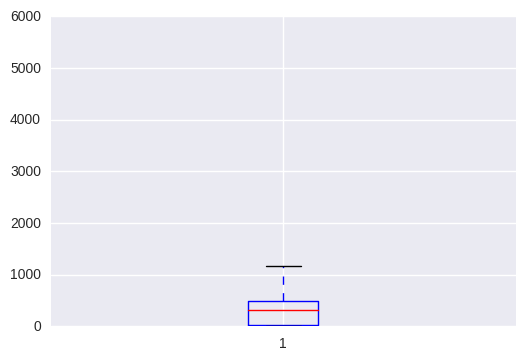

```python
bplot1 = plt.boxplot(df.IndividualRate)
```

#### Show the distribution of ‘IndividualRate’ values using boxplot and histogram

```python
df =  df[df. IndividualRate < 9000]
df =  df[df. IndividualRate > 0]
```

```python
df.IndividualRate.min()
df.IndividualRate.max()
```

```
0.01
```

```
5319.8900000000003
```

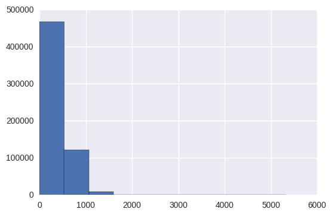

```python
temp = plt.hist(df.IndividualRate)
```

```python
df.IndividualRate.kurt()
df.IndividualRate.skew()
```

```
3.8813843680416409
```

```
1.1515103873623105
```

```python
df.IndividualRate.min()
df.IndividualRate.max()
```

```
0.01
```

```
5319.8900000000003
```

# Task 3.2

Prepare the data for the later tasks, extract the rows where ‘IndividualRate’ is greater than 0 and less than 9000.

```python
StateCode_list = df.StateCode.unique()
StateCode_list = np.sort(StateCode_list)
```

```python
StateCode_Name = []
for i in StateCode_list:
        g = geocoder.google(i,components="administrative_area:%s|country:US" %(i))
        t = g.address.partition(",")
        StateCode_Name.append(t[0].encode("utf-8"))
```

- compare the number of carries (i.e., issuers)
- total number pf plans

```python
print("Listed Carries: ",len(df.IssuerId.unique()))
print("Listed Plans: ",len(df.PlanId.unique()))
print("Listed States: ",len(df.StateCode.unique()))
```

```
('Listed Carries: ', 871)
('Listed Plans: ', 15427)
('Listed States: ', 39)
```

## Number of Issuers by States of US

```python
number_providers = df[['IssuerId','PlanId']].groupby(df['StateCode']).agg(['nunique'])
number_providers.columns = number_providers.columns.droplevel(1)
```

```python
layout = go.Layout(title='Number of Issuers by US State',yaxis=dict(title='Number of Issuers',titlefont=dict(family='Courier New, monospace',size=18,)))

data = [go.Bar(x=list(number_providers.index), y=list(number_providers.IssuerId))]
fig = go.Figure(data=data, layout=layout)
py.iplot(fig,filename='Number_of_Issuers_by_US_State')
```

[interactive chart not shown]

## Number of Policies by States of US

```python
layout = go.Layout(title='Number of Plans by US State',yaxis=dict(title='Number of Plans',titlefont=dict(family='Courier New, monospace',size=18,)))

data = [go.Bar(x=list(number_providers.index), y=list(number_providers.PlanId))]
fig = go.Figure(data=data, layout=layout)
py.iplot(fig,filename='Number_of_Plans_by_US_State')
```

[interactive chart not shown]

```python
bubbleDF = pd.DataFrame()
bubbleDF['State'] = StateCode_Name
bubbleDF['numberIssuers'] = list(number_providers.IssuerId)
bubbleDF['numberPlanId'] = list(number_providers.PlanId)
bubbleDF.head()
```

|  | State | numberIssuers | numberPlanId |
| --- | --- | --- | --- |
| 0 | Alaska | 12 | 174 |
| 1 | Alabama | 19 | 155 |
| 2 | Arkansas | 15 | 214 |
| 3 | Arizona | 36 | 654 |
| 4 | Delaware | 12 | 110 |

# Import us census data for population estimates for 2014

```python
population = pd.read_csv('us_statedata.csv',thousands=",")
population.head()
```

|  | State | Population |
| --- | --- | --- |
| 0 | Alabama | 4843214 |
| 1 | Alaska | 736705 |
| 2 | Arizona | 6719993 |
| 3 | Arkansas | 2966912 |
| 4 | California | 38680810 |

```python
df2 = pd.merge(bubbleDF, population, on='State',how='inner')
df2.head(5)
```

|  | State | numberIssuers | numberPlanId | Population |
| --- | --- | --- | --- | --- |
| 0 | Alaska | 12 | 174 | 736705 |
| 1 | Alabama | 19 | 155 | 4843214 |
| 2 | Arkansas | 15 | 214 | 2966912 |
| 3 | Arizona | 36 | 654 | 6719993 |
| 4 | Delaware | 12 | 110 | 934948 |

```python
cf.set_config_file(theme='ggplot')
```

```python
df2.iplot(kind='bubble', x='numberIssuers', y='numberPlanId', size='Population', text='State',
             xTitle='numberof Issuers', yTitle='number of Plans',title= "Population of USA States 2014 - Issuers to Policies")
```

[interactive chart not shown]

# Questions - Task 3.2

### Whether there are more plans for where there are larger populations?

THe above graph would indicatre that based on population there are more plociy issuers and plans the larger hte population

### which state has the largest/least number of health insurance issuers or plans?

Texas would appear from this graph to have the largest number of health insurance issuers, however Wisconsin has per capaita the highest rate for both policies and plans.

### whether there are more plans for where there are larger populations?

the above information would indicate that the above statement is true

# Task 3.3

- How many issuers offers plans to non-smokers vs. smokers across different states?

### remove all NaN values from dataframe to create IndividualTobaccoRate dataframe

```python
tRate_DF = df.dropna()
```

### Group by state and do a unique count on number of issuers with smoking policies

```python
plans_smoking = tRate_DF[['IssuerId', 'PlanId']].groupby(tRate_DF['StateCode']).agg(['nunique'])
plans_smoking.columns = plans_smoking.columns.droplevel(1)
```

### Graph of Policy issuers with smoking policies

```python
layout = go.Layout(barmode='group',title='Number of Issuers per State - Smoker -V- NonSmoker Plans', yaxis=dict(title='Number of Plans',titlefont=dict(family='Courier New, monospace',size=18,)))
dataZ = go.Bar(x=StateCode_Name, y=list(number_providers.IssuerId), name='Total Issuers')
dataX = go.Bar(x=StateCode_Name, y=list(plans_smoking.IssuerId), name='Issuers with Smoker only Plans')
data = [dataX, dataZ]
fig = go.Figure(data=data, layout=layout)
py.iplot(fig, filename='Number_of_Issuers_per_State_Smoker_V_NonSmoker_Plans')
```

[interactive chart not shown]

### Graph of Plans with smoking policies

```python
layout = go.Layout(barmode='group',title='Number of Plans per State - Smoker -V- Non', yaxis=dict(title='Number of Plans',titlefont=dict(family='Courier New, monospace',size=18,)))
dataZ = go.Bar(x=StateCode_Name, y=list(number_providers.PlanId), name='Total Plans')
dataX = go.Bar(x=StateCode_Name, y=list(plans_smoking.PlanId), name='Smoking Plans')
data = [dataX, dataZ]
fig = go.Figure(data=data, layout=layout)
py.iplot(fig, filename='Number_of_Plans_per_State_Smoker_V_Non')
```

[interactive chart not shown]

### Do all states provided plans for tobacco users?

```python
no_tab_policy = df[['IndividualTobaccoRate']].groupby(df['StateCode']).agg(['nunique'])
no_tab_policy.columns = no_tab_policy.columns.droplevel(1)
no_tab_policy = no_tab_policy.loc[no_tab_policy['IndividualTobaccoRate'] < 1]
no_tab = list(no_tab_policy.index)
no_tab_name= []
for i in no_tab:
        g = geocoder.google(i,components="administrative_area:%s|country:US" %(i))
        t = g.address.partition(",")
        no_tab_name.append(t[0].encode("utf-8"))
print "These States have No policies for Smokers: ", no_tab_name
```

```
These States have No policies for Smokers:  ['New Jersey']
```

# Task 3.4

```python
mean_plan_price = df[['IndividualTobaccoRate', 'IndividualRate']].groupby(df['StateCode']).agg(['mean'])
mean_plan_price.columns = mean_plan_price.columns.droplevel(1)
```

```python
layout = go.Layout(barmode='group',title='Mean Price of Plans- Smoker -V- Non', yaxis=dict(title='Cost of Plans',titlefont=dict(family='Courier New, monospace',size=18,)))
dataZ = go.Bar(x=StateCode_Name, y=list(mean_plan_price.IndividualRate), name='Non Smoking Plans')
dataX = go.Bar(x=StateCode_Name, y=list(mean_plan_price.IndividualTobaccoRate), name='Smoking Plans')
data = [dataX, dataZ]
fig = go.Figure(data=data, layout=layout)
py.iplot(fig, filename='Mean_Price_of_Plans_Smoker_V_Non')
```

[interactive chart not shown]

# Task 3.5

```python
df.head()
```

|  | BusinessYear | StateCode | IssuerId | PlanId | Age | IndividualRate | IndividualTobaccoRate |
| --- | --- | --- | --- | --- | --- | --- | --- |
| 0 | 2016 | MI | 47638 | 47638MI0010001 | 40 | 31.98 | NaN |
| 1 | 2015 | SC | 56571 | 56571SC0030002 | 56 | 25.24 | NaN |
| 2 | 2014 | FL | 48129 | 48129FL0110001 | 37 | 27.60 | NaN |
| 3 | 2016 | TN | 22384 | 22384TN0040002 | 54 | 33.77 | NaN |
| 4 | 2014 | FL | 59667 | 59667FL0020003 | 42 | 15.77 | NaN |

```python
df = df.drop(df[df.Age == 'Family Option'].index)
df['Age'] = df['Age'].replace(['0-20'], '20')
df['Age'] = df['Age'].replace(['65 and over'], '65')
age_mean = df[['IndividualRate', 'IndividualTobaccoRate']].groupby(df['Age']).agg(['mean'])
age_mean.columns = age_mean.columns.droplevel(1)
```

```python
layout = go.Layout(barmode='group',title='Mean Policy Cost based on Age', xaxis=dict(title='Age',titlefont=dict(family='Courier New, monospace',size=18,)),yaxis=dict(title='Mean Cost of Plan',titlefont=dict(family='Courier New, monospace',size=18,)))
dataZ = go.Scatter(x=list(age_mean.index), y=list(age_mean.IndividualRate),
                   name='Non Smoker',
                   mode = 'lines+markers')
dataX = go.Scatter(x=list(age_mean.index), y=list(age_mean.IndividualTobaccoRate),
                   mode = 'lines+markers',
                   name = 'Smoker')
data = [dataX, dataZ]
fig = go.Figure(data=data, layout=layout)
py.iplot(fig, filename='Mean_Policy_Cost_based_on_Age')
```

[interactive chart not shown]

# Questions - Task 3.5

### As a whole, compare the average rates/cost for non-smokers vs. smokers at different ages. how does the rates looks like as age of the subscriber increases?

As you can see from the above graph there is a definate increase for both smokers and non smokers on ayarage in the US. however ther is a definate increase in the rate of mean cost for smokers as they get older

```python
age_list = df.Age.unique()
age_list = np.sort(age_list)
```

### Generate Mean Price by Age and State

```python
df2 = df.copy()
df2.set_index(['StateCode', 'Age'], inplace=True)
df2 = df2.groupby(level=[0,1]).mean()
columnNames = ['IndividualRate', 'IndividualTobaccoRate']
df2 = df2[columnNames]
df2.head(5)
```

| StateCode | Age | IndividualRate | IndividualTobaccoRate |
| --- | --- | --- | --- |
| AK | 20 | 242.377396 | 223.600 |
|  | 21 | 428.908539 | 474.700 |
|  | 22 | 402.013956 | 448.875 |
|  | 23 | 423.747792 | 451.250 |
|  | 24 | 399.064125 | 426.800 |

### Remove all Index's to reset State Code as the only index

```python
df2.reset_index(inplace=True)
df2.head(5)
```

|  | StateCode | Age | IndividualRate | IndividualTobaccoRate |
| --- | --- | --- | --- | --- |
| 0 | AK | 20 | 242.377396 | 223.600 |
| 1 | AK | 21 | 428.908539 | 474.700 |
| 2 | AK | 22 | 402.013956 | 448.875 |
| 3 | AK | 23 | 423.747792 | 451.250 |
| 4 | AK | 24 | 399.064125 | 426.800 |

```python
columnNames = ['StateCode', 'Age','IndividualRate','IndividualTobaccoRate']
df2 = df2[columnNames]
df2 = df2.set_index(df2.StateCode)
df2.head(5)
```

| StateCode | StateCode | Age | IndividualRate | IndividualTobaccoRate |
| --- | --- | --- | --- | --- |
| AK | AK | 20 | 242.377396 | 223.600 |
| AK | AK | 21 | 428.908539 | 474.700 |
| AK | AK | 22 | 402.013956 | 448.875 |
| AK | AK | 23 | 423.747792 | 451.250 |
| AK | AK | 24 | 399.064125 | 426.800 |

```python
columnNames = ['Age','IndividualRate','IndividualTobaccoRate']
df2 = df2[columnNames]
df2.head(5)
```

| StateCode | Age | IndividualRate | IndividualTobaccoRate |
| --- | --- | --- | --- |
| AK | 20 | 242.377396 | 223.600 |
| AK | 21 | 428.908539 | 474.700 |
| AK | 22 | 402.013956 | 448.875 |
| AK | 23 | 423.747792 | 451.250 |
| AK | 24 | 399.064125 | 426.800 |

```python
layout = go.Layout(barmode='group',title='Mean Policy Cost based on Age All states', xaxis=dict(title='Age',titlefont=dict(family='Courier New, monospace',size=18,)),yaxis=dict(title='Mean Cost of Plan',titlefont=dict(family='Courier New, monospace',size=18,)))
dataZ = go.Scatter(x=list(df2.Age), y=list(df2.IndividualRate),
                   name='Non Smoker',
                   mode = 'lines+markers')
dataX = go.Scatter(x=list(df2.Age), y=list(df2.IndividualTobaccoRate),
                   mode = 'lines+markers',
                   name = 'Smoker')
data = [dataX, dataZ]
fig = go.Figure(data=data, layout=layout)
py.iplot(fig, filename='Mean_Policy_cost_based_on_Age_All_states')
```

[interactive chart not shown]

### This graph is not particularly helpful,however what it has plotted is the mean cost by age for smokers and non smokers for every state in the US.

### At which states the changes of non-smoker and smoker look parallel, and at which states the tobacco user rate has a bigger slope?

The next set of graphs could not be produced any other way, i aploogise i tried numerous ways in an attempt to produce sub plots. this is the only way i could show every state.

```python
figure = {'data': [],'layout': {}}
#figure['data'].append
#figure['layout'] = layout
j = 0
for i in StateCode_list:
    tempDF = pd.DataFrame()
    tempDF = df2.ix[df2.index == i]
    layout = go.Layout(barmode='group',title='%s  - Mean Policy Cost based on Age' %StateCode_Name[j], xaxis=dict(title='Age',titlefont=dict(family='Courier New, monospace',size=18,)),yaxis=dict(title='Mean Cost of Plan',titlefont=dict(family='Courier New, monospace',size=18,)))
    dataZ = go.Scatter(x=list(tempDF.Age), y=list(tempDF.IndividualRate),
                   name='Non Smoker',
                   mode = 'lines+markers')
    dataX = go.Scatter(x=list(tempDF.Age), y=list(tempDF.IndividualTobaccoRate),
                   mode = 'lines+markers',
                   name = 'Smoker')
    data = [dataX, dataZ]
    del tempDF
    j = j + 1
    fig = go.Figure(data=data, layout=layout)
    py.iplot(fig,filename='Mean_Policy_Cost_based_Age_%s' %i)
```

[interactive chart not shown]

### At which states the changes of non-smoker and smoker look parallel, and at which states the tobacco user rate has a bigger slope?

# Task 4

- Exploratory Analysis on another data set
- US green house emissions data set was used from kaggle

https://www.kaggle.com/sogun3/uspollution

- I am attempting to plot the different types of emissions over time and by state

```python
df = pd.read_csv('pollution_us_2000_2016.csv')
```

```python
df.dtypes
```

```
Unnamed: 0             int64
State Code             int64
County Code            int64
Site Num               int64
Address               object
State                 object
County                object
City                  object
Date Local            object
NO2 Units             object
NO2 Mean             float64
NO2 1st Max Value    float64
NO2 1st Max Hour       int64
NO2 AQI                int64
O3 Units              object
O3 Mean              float64
O3 1st Max Value     float64
O3 1st Max Hour        int64
O3 AQI                 int64
SO2 Units             object
SO2 Mean             float64
SO2 1st Max Value    float64
SO2 1st Max Hour       int64
SO2 AQI              float64
CO Units              object
CO Mean              float64
CO 1st Max Value     float64
CO 1st Max Hour        int64
CO AQI               float64
dtype: object
```

#### Remove unwanted columns

```python
df = df.drop('Unnamed: 0', 1)
df = df.drop('County Code', 1)
df = df.drop('Site Num', 1)
df = df.drop('State Code', 1)
df = df.drop('Address', 1)
df = df.drop('County', 1)
df = df.drop('NO2 Units', 1)
df = df.drop('NO2 1st Max Hour', 1)
df = df.drop('O3 Units', 1)
df = df.drop('O3 1st Max Hour', 1)
df = df.drop('SO2 Units', 1)
df = df.drop('SO2 1st Max Hour', 1)
df = df.drop('CO Units', 1)
df = df.drop('CO 1st Max Hour', 1)
```

#### set dateime index

```python
df = df.set_index(pd.DatetimeIndex(df['Date Local']))
df = df.drop('Date Local', 1)
```

#### Create a year variable for later grouping

```python
df['year'] = df.index.year
```

#### rename variables for easier indexing

```python
df = df.rename(columns={'O3 Mean':'Ozone_mean'})
df = df.rename(columns={'O3 1st Max Value':'Ozone_max'})
df = df.rename(columns={'CO Mean':'Carbon_mean'})
df = df.rename(columns={'CO 1st Max Value':'Carbon_max'})
df = df.rename(columns={'O3 AQI':'Ozone_AQI'})
df = df.rename(columns={'CO AQI':'Carbon_AQI'})
df = df.rename(columns={'SO2 Mean':'Sulphur_mean'})
df = df.rename(columns={'SO2 1st Max Value':'Sulphur_max'})
df = df.rename(columns={'SO2 AQI':'Sulphur_AQI'})
df = df.rename(columns={'NO2 Mean':'Nitrogen_mean'})
df = df.rename(columns={'NO2 1st Max Value':'Nitrogen_max'})
df = df.rename(columns={'NO2 AQI':'Nitrogen_AQI'})
df.head(2)
```

| Date Local | State | City | Nitrogen_mean | Nitrogen_max | Nitrogen_AQI | Ozone_mean | Ozone_max | Ozone_AQI | Sulphur_mean | Sulphur_max | Sulphur_AQI | Carbon_mean | Carbon_max | Carbon_AQI | year |
| --- | --- | --- | --- | --- | --- | --- | --- | --- | --- | --- | --- | --- | --- | --- | --- |
| 2000-01-01 | Arizona | Phoenix | 19.041667 | 49.0 | 46 | 0.0225 | 0.04 | 34 | 3.0 | 9.0 | 13.0 | 1.145833 | 4.2 | NaN | 2000 |
| 2000-01-01 | Arizona | Phoenix | 19.041667 | 49.0 | 46 | 0.0225 | 0.04 | 34 | 3.0 | 9.0 | 13.0 | 0.878947 | 2.2 | 25.0 | 2000 |

```python
AQI = df[['Nitrogen_AQI','Ozone_AQI', 'Sulphur_AQI', 'Carbon_AQI']].groupby(df['year']).agg(['mean'])
AQI.columns = AQI.columns.droplevel(1)
```

```python
pollution = df[['Ozone_mean','Ozone_max', 'Carbon_mean', 'Carbon_max', 'Sulphur_mean', 'Sulphur_max','Nitrogen_mean' ,'Nitrogen_max']].groupby(df['year']).agg(['mean'])
pollution.columns = pollution.columns.droplevel(1)
```

```python
layout = go.Layout(barmode='group',title='US Air Quality Index 2000 - 2016', yaxis=dict(title='Air Quality Index',titlefont=dict(family='Courier New, monospace',size=18,)))
dataZ = go.Scatter(x=AQI.index, y=list(AQI.Nitrogen_AQI), name='Nitrogen AQI',mode ='lines+markers')
dataX = go.Scatter(x=AQI.index, y=list(AQI.Ozone_AQI), name='Ozone AQI', mode ='lines+markers')

dataA = go.Scatter(x=AQI.index, y=list(AQI.Sulphur_AQI), name='Sulphur AQI',mode ='lines+markers')
dataB = go.Scatter(x=AQI.index, y=list(AQI.Carbon_AQI), name='Carbon AQI', mode ='lines+markers')


data = [dataX, dataZ, dataA, dataB]
fig = go.Figure(data=data, layout=layout)
py.iplot(fig, filename='US_Air_Quality_Index_2000_2016')
```

[interactive chart not shown]

## Overall air quality seems to be improving since 2000

https://en.wikipedia.org/wiki/Air_quality_index

An air quality index (AQI) is a number used by government agencies [1] to communicate to the public how polluted the air currently is or how polluted it is forecast to become.As the AQI increases, an increasingly large percentage of the population is likely to experience increasingly severe adverse health effects

```python
layout = go.Layout(barmode='group',title='US Nitrogen Dixoide Emssions 2000 - 2016', yaxis=dict(title='Parts per Million',titlefont=dict(family='Courier New, monospace',size=18,)))
dataZ = go.Scatter(x=pollution.index, y=list(pollution.Nitrogen_mean), name='Nitrogen Emmssions Mean',mode ='lines+markers')
dataX = go.Scatter(x=pollution.index, y=list(pollution.Nitrogen_max), name='Nitrogen Emmssions Max', mode ='lines+markers')

data = [dataX, dataZ]
fig = go.Figure(data=data, layout=layout)
py.iplot(fig, filename='US_Nitrogen_Dixoide_Emssions_2000_2016')
```

[interactive chart not shown]

```python
layout = go.Layout(barmode='group',title='US Sulphur Dixoide Emssions 2000 - 2016', yaxis=dict(title='Parts per Million',titlefont=dict(family='Courier New, monospace',size=18,)))
dataZ = go.Scatter(x=pollution.index, y=list(pollution.Sulphur_mean), name='Sulphur Dixoide Emmssions Mean',mode ='lines+markers')
dataX = go.Scatter(x=pollution.index, y=list(pollution.Sulphur_max), name='Sulphur Dixoide Emmssions Max', mode ='lines+markers')

data = [dataX, dataZ]
fig = go.Figure(data=data, layout=layout)
py.iplot(fig, filename='US_Sulphur_Dixoide_Emssions_2000_2016')
```

[interactive chart not shown]

```python
layout = go.Layout(barmode='group',title='US Ozone Emssions 2000 - 2016', yaxis=dict(title='Parts per Million',titlefont=dict(family='Courier New, monospace',size=18,)))
dataZ = go.Scatter(x=pollution.index, y=list(pollution.Ozone_mean), name='Ozone Emmssions Mean',mode ='lines+markers')
dataX = go.Scatter(x=pollution.index, y=list(pollution.Ozone_max), name='Ozone Emmssions Max', mode ='lines+markers')

data = [dataX, dataZ]
fig = go.Figure(data=data, layout=layout)
py.iplot(fig, filename='US_Ozone_Emssions_2000_2016')
```

[interactive chart not shown]

```python
layout = go.Layout(barmode='group',title='US Carbon Emssions 2000 - 2016', yaxis=dict(title='Parts per Million',titlefont=dict(family='Courier New, monospace',size=18,)))
dataZ = go.Scatter(x=pollution.index, y=list(pollution.Carbon_mean), name='Carbon Emmssions Mean',mode ='lines+markers')
dataX = go.Scatter(x=pollution.index, y=list(pollution.Carbon_max), name='Carbon Emmssions Max', mode ='lines+markers')

data = [dataX, dataZ]
fig = go.Figure(data=data, layout=layout)
py.iplot(fig,filename='US_Carbon_Emssions_2000_2016')
```

[interactive chart not shown]

### At this point i want to demonstrate the overall mean AQI per state

```python
df2 = df.copy()
df2.set_index(['State', 'year'], inplace=True)
df2 = df2.groupby(level=[0,1]).mean()
```

```python
df2.reset_index(inplace=True)
df2 = df2.set_index(df2.State)
df2.head(5)
```

| State | State | year | Nitrogen_mean | Nitrogen_max | Nitrogen_AQI | Ozone_mean | Ozone_max | Ozone_AQI | Sulphur_mean | Sulphur_max | Sulphur_AQI | Carbon_mean | Carbon_max | Carbon_AQI |
| --- | --- | --- | --- | --- | --- | --- | --- | --- | --- | --- | --- | --- | --- | --- |
| Alabama | Alabama | 2013 | 12.065635 | 23.141935 | 21.387097 | 0.012099 | 0.020387 | 18.903226 | 0.750311 | 3.609677 | 6.580645 | 0.211007 | 0.440323 | 4.129032 |
| Alabama | Alabama | 2014 | 9.411746 | 23.215423 | 21.495854 | 0.024660 | 0.038869 | 36.983416 | 1.186517 | 4.746932 | 7.956954 | 0.205921 | 0.389561 | 3.711443 |
| Alabama | Alabama | 2015 | 9.078580 | 21.699000 | 20.026667 | 0.024000 | 0.038627 | 37.343333 | 1.009429 | 4.243500 | 6.950000 | 0.221027 | 0.419567 | 3.933333 |
| Alabama | Alabama | 2016 | 9.524873 | 24.991946 | 23.093960 | 0.028348 | 0.040919 | 39.295302 | 0.835118 | 3.286913 | 5.275168 | 0.209514 | 0.412081 | 3.906040 |
| Alaska | Alaska | 2014 | 11.658510 | 22.701676 | 21.167598 | 0.010307 | 0.016385 | 15.206704 | 5.951531 | 9.356704 | 14.000000 | 0.455444 | 0.715922 | 6.983240 |

```python
columnNames = ['Nitrogen_AQI','Ozone_AQI','Sulphur_AQI', 'Carbon_AQI', 'year']
df2 = df2[columnNames]
df2.head(5)
```

| State | Nitrogen_AQI | Ozone_AQI | Sulphur_AQI | Carbon_AQI | year |
| --- | --- | --- | --- | --- | --- |
| Alabama | 21.387097 | 18.903226 | 6.580645 | 4.129032 | 2013 |
| Alabama | 21.495854 | 36.983416 | 7.956954 | 3.711443 | 2014 |
| Alabama | 20.026667 | 37.343333 | 6.950000 | 3.933333 | 2015 |
| Alabama | 23.093960 | 39.295302 | 5.275168 | 3.906040 | 2016 |
| Alaska | 21.167598 | 15.206704 | 14.000000 | 6.983240 | 2014 |

```python
df2['overall_AQI'] = df2['Nitrogen_AQI']+df2['Ozone_AQI']+df2['Sulphur_AQI']+df2['Carbon_AQI']
```

```python
trace1 = Scatter3d(
    y=df2.year,
    z=df2.overall_AQI,
    x=df2.index,
    text=df2.index,
    mode='markers',
    marker=dict(
        sizemode='diameter',
        sizeref=750,
        size=df2.overall_AQI*150,
        color = df2.overall_AQI,
        colorscale = 'Jet',
        colorbar = dict(title = 'Air Quality Index'),
        line=dict(color='rgb(140, 140, 170)')
    )
)

data=[trace1]
layout=dict(height=800, width=800, title='US States Air Quality Index 2000 - 2016',scene=Scene(aspectmode="manual"))
fig=dict(data=data, layout=layout)
py.iplot(fig, filename='3DBubble')
```

[interactive chart not shown]

### This graph demonstrates that over the last 16 years that there has been an overall improvement in Air Quality in the United States.

The dark red values denote poor air quality - Michigan in 2001 had the worst results and Tennesse in 2016 have the best results.